# Estratégia em Finanças - Artigo

# Now let’s split the data between Brumadinho and Mariana

## Mariana

Splitting the dataset between 05/10/2015 (t=442) and 04/12/2015 (t=485). The disaster occured on 05/11/2015. So we are going to use as split t=465 (05/11/2015).

```r
mariana <- data_frame4[which(data_frame4$Data == '2015-10-05'):which(data_frame4$Data == '2015-12-07'),]
mariana <- mariana[-nrow(mariana),]

dim(mariana)
```

```
## [1] 1100    8
```

```r
head(mariana)
```

```
##       Time       Data Company      Return   Volume  Max_Amp Daily_Amp
## 11026  442 2015-10-05     ACH  0.03382247    74800 0.180000  0.140000
## 11027  442 2015-10-05    SCCO  0.02644897  1312100 0.709999  0.540001
## 11028  442 2015-10-05      AA  0.08937203 20160200 2.042549  1.922399
## 11029  442 2015-10-05     URG  0.09844007   196100 0.060000  0.050000
## 11030  442 2015-10-05     XPL -0.08515781    51400 0.030000 -0.030000
## 11031  442 2015-10-05     BBL  0.01171049  1786000 0.870001  0.630001
##       Company_index
## 11026             2
## 11027            17
## 11028             1
## 11029            22
## 11030            25
## 11031             4
```

```r
tail(mariana)
```

```
##       Time       Data Company      Return   Volume  Max_Amp Daily_Amp
## 12120  485 2015-12-04     UEC -0.01869213   381400 0.050000 -0.030000
## 12121  485 2015-12-04    VALE -0.04179713 20727200 0.100000 -0.030000
## 12122  485 2015-12-04     URG  0.00000000   303900 0.050000  0.010000
## 12123  485 2015-12-04     CCJ  0.01917524  1683500 0.470000  0.230000
## 12124  485 2015-12-04    ARNC  0.03819338 13125800 0.854572  0.697152
## 12125  485 2015-12-04    VEDL  0.02904015   127100 0.170000  0.080000
##       Company_index
## 12120            21
## 12121            23
## 12122            22
## 12123             6
## 12124             3
## 12125            24
```

```r
vale_controle <- dataprep(
  foo=mariana,
  predictors = c('Volume', 'Max_Amp', 'Daily_Amp'),
  predictors.op = 'mean',
  time.predictors.prior = 442:465,
  dependent = 'Return',
  unit.variable = 'Company_index',
  unit.names.variable = 'Company',
  time.variable = 'Time',
  treatment.identifier = 23,
  controls.identifier = Controles,
  time.optimize.ssr = 442:465,
  time.plot = 442:485)

out <- synth(data.prep.obj = vale_controle,optimxmethod = 'BFGS')
```

```
##
## X1, X0, Z1, Z0 all come directly from dataprep object.
##
##
## ****************
##  searching for synthetic control unit
##
##
## ****************
## ****************
## ****************
##
## MSPE (LOSS V): 0.0009586571
##
## solution.v:
##  0.9248193 0.06104628 0.01413444
##
## solution.w:
##  2.69e-08 1.42e-08 9.8e-09 8.1e-09 9.1e-09 1e-08 0.2155199 8.3e-09 0.7844798 4.9e-09 1.07e-08 7.7e-09 1.38e-08 1.41e-08 1.55e-08 1.11e-08 9.5e-09 4.1e-09 1.72e-08 5.65e-08 6.2e-09 9.3e-09 1.14e-08 1.4e-09
```

```r
tabelas <- synth.tab(synth.res = out,dataprep.res = vale_controle,round.digit = 3)
print(tabelas)
```

```
## $tab.pred
##               Treated  Synthetic Sample Mean
## Volume    28403387.50 2.7513e+07 3802233.854
## Max_Amp          0.22 6.3600e-01       0.351
## Daily_Amp       -0.02 4.6000e-02       0.013
##
## $tab.v
##           v.weights
## Volume    0.925
## Max_Amp   0.061
## Daily_Amp 0.014
##
## $tab.w
##    w.weights unit.names unit.numbers
## 1      0.000         AA            1
## 2      0.000        ACH            2
## 3      0.000       ARNC            3
## 4      0.000        BBL            4
## 5      0.000        BHP            5
## 6      0.000        CCJ            6
## 7      0.216        CLF            7
## 8      0.000        CMC            8
## 9      0.784        FCX            9
## 10     0.000        GMO           10
## 11     0.000        HBM           11
## 12     0.000        HSC           12
## 13     0.000        LAC           13
## 14     0.000        MTL           14
## 15     0.000        PLM           15
## 16     0.000        RIO           16
## 17     0.000       SCCO           17
## 18     0.000        TGB           18
## 19     0.000        TRQ           19
## 20     0.000       UAMY           20
## 21     0.000        UEC           21
## 22     0.000        URG           22
## 24     0.000       VEDL           24
## 25     0.000        XPL           25
##
## $tab.loss
##        Loss W       Loss V
## [1,] 0.246501 0.0009586571
```

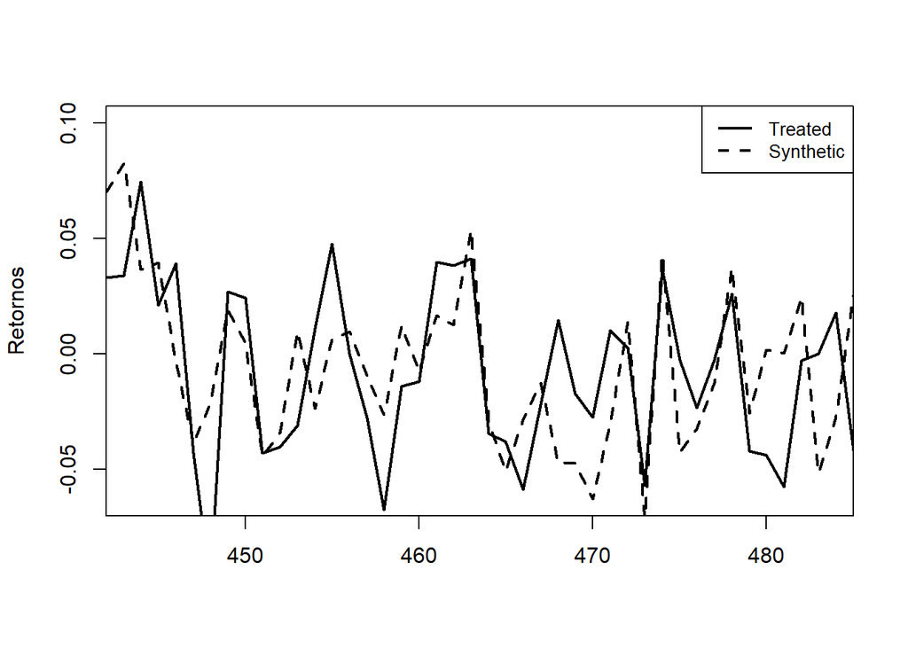

```r
path_plot<-path.plot(synth.res = out,dataprep.res = vale_controle,Ylab = 'Retornos',Xlab='')
```

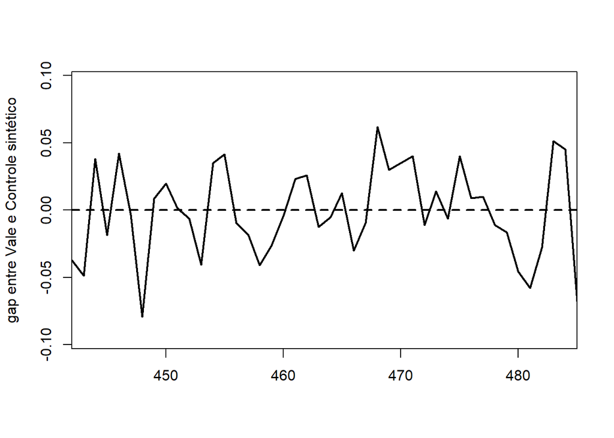

```r
gaps.plot(synth.res = out,dataprep.res = vale_controle,Main = '',Xlab = '',Ylab = 'gap entre Vale e Controle sintético')
```

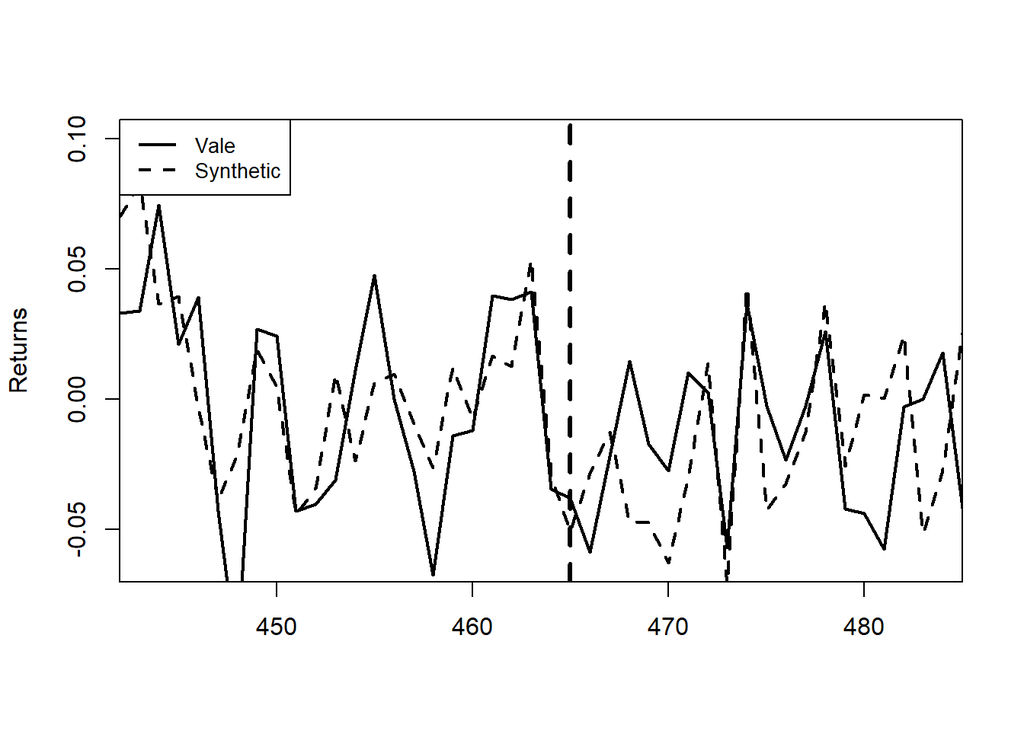

```r
#stargazer(tabelas$tab.pred,type = 'html',title = 'estimado controle e tratado')
#stargazer(tabelas$tab.v,type = 'html',title = 'Pesos das variáveis')

#pdf(file = "D:\\Onedrive - Aisha\\OneDrive\\Documentos\\Graduação Economia UDESC\\2019-1\\Estratégia em Finanças - Daniel\\Artigo da disciplina\\Fig_valesynth.pdf", width = 12, height = 6)
path.plot(synth.res    = out,
          dataprep.res = vale_controle,
          Ylab         = c("Returns"),
          Xlab         = c(""),
          Legend       = c("Vale","Synthetic"),
          Legend.position = c("topleft")
)
abline(v=465, lty=2, lwd=3)
```

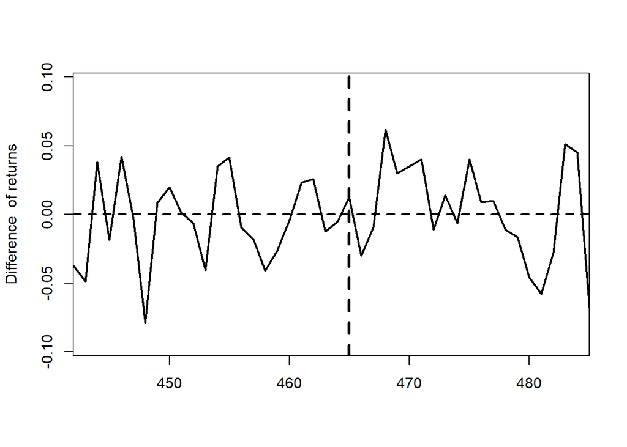

```r
#dev.off()

#pdf(file = "D:\\Onedrive - Aisha\\OneDrive\\Documentos\\Graduação Economia UDESC\\2019-1\\Estratégia em Finanças - Daniel\\Artigo da disciplina\\Fig_valediff.pdf", width = 12, height = 6)
gaps.plot(synth.res = out,dataprep.res = vale_controle,  Main = '',Xlab = '',Ylab = 'Difference  of returns')
abline(v=465, lty=2, lwd=3)
```

```r
#dev.off()

placebos <- generate.placebos(dataprep.out =  vale_controle, synth.out = out)
```

[output not shown]

[output cut: 424 more lines]

```
## ****************
##  searching for synthetic control unit
##
##
## ****************
## ****************
## ****************
##
## MSPE (LOSS V): 0.00467873
##
## solution.v:
##  0.4037502 0.02666713 0.5695827
##
## solution.w:
##  0.0001359518 3.5879e-06 0.0001064041 0.0006786528 0.0004946238 0.0005879943 7.83845e-05 0.000544966 7.94374e-05 0.4249041 0.001433526 0.0007359776 0.1141036 0.002520607 0.002036287 0.0003919742 0.0006975534 1.8381e-06 0.0004941933 0.4458477 0.0009408441 0.001801398 0.001380337
```

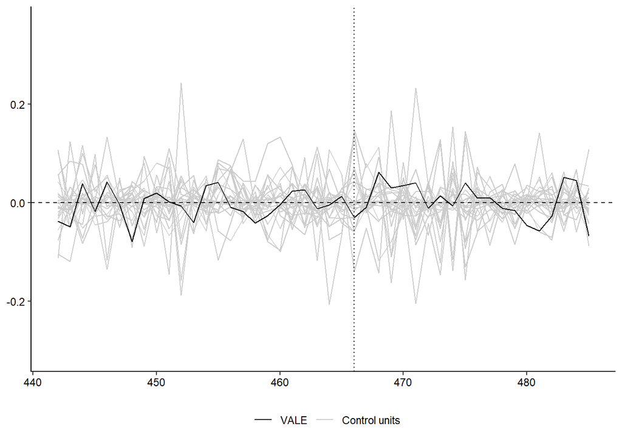

```r
#mspe.plot(placebos, discard.extreme = TRUE, mspe.limit = 20, plot.hist = FALSE)

#pdf(file = "D:\\Onedrive - Aisha\\OneDrive\\Documentos\\Graduação Economia UDESC\\2019-1\\Estratégia em Finanças - Daniel\\Artigo da disciplina\\Fig_marianaplacebo.pdf", width = 12, height = 6)
plot.placebos(placebos)
```

```r
#dev.off()
```

## Brumadinho

Splitting the dataset between 26/12/2018 (t=1254) and 25/02/2019 (t=1294). The disaster occured on 25/01/2019. So we are going to use as split t=1274 (25/01/2019).

```r
brumadinho <- data_frame4[which(data_frame4$Data == '2018-12-26'):which(data_frame4$Data == '2019-02-26'),]
brumadinho <- brumadinho[-nrow(brumadinho),]

dim(brumadinho)
```

```
## [1] 1025    8
```

```r
head(brumadinho)
```

```
##       Time       Data Company     Return   Volume  Max_Amp Daily_Amp
## 31326 1254 2018-12-26    VALE 0.03662271 16587500 0.520000      0.39
## 31327 1254 2018-12-26     UEC 0.04959694  1122200 0.120000      0.07
## 31328 1254 2018-12-26      AA 0.07615072  3237100 2.190001      1.83
## 31329 1254 2018-12-26     URG 0.01709443   373500 0.090000      0.01
## 31330 1254 2018-12-26     CLF 0.05774535  7169100 0.630000      0.48
## 31331 1254 2018-12-26     CCJ 0.05166532  1516000 0.620000      0.57
##       Company_index
## 31326            23
## 31327            21
## 31328             1
## 31329            22
## 31330             7
## 31331             6
```

```r
tail(brumadinho)
```

```
##       Time       Data Company       Return   Volume  Max_Amp Daily_Amp
## 32345 1294 2019-02-25     XPL  0.000000000    49400 0.020000     -0.02
## 32346 1294 2019-02-25    VALE  0.003992021 23818300 0.230000     -0.02
## 32347 1294 2019-02-25     URG  0.000000000   234900 0.010000      0.00
## 32348 1294 2019-02-25     BBL -0.003994518   796300 0.290001      0.16
## 32349 1294 2019-02-25     PLM -0.014184635   338800 0.030000     -0.02
## 32350 1294 2019-02-25     BHP -0.002581580  1826700 0.450001      0.16
##       Company_index
## 32345            25
## 32346            23
## 32347            22
## 32348             4
## 32349            15
## 32350             5
```

```r
vale_controle <- dataprep(
  foo=brumadinho,
  predictors = c('Volume', 'Max_Amp', 'Daily_Amp'),
  predictors.op = 'mean',
  time.predictors.prior = 1254:1274,
  dependent = 'Return',
  unit.variable = 'Company_index',
  unit.names.variable = 'Company',
  time.variable = 'Time',
  treatment.identifier = 23,
  controls.identifier = Controles,
  time.optimize.ssr = 1254:1274,
  time.plot = 1254:1294)

out <- synth(data.prep.obj = vale_controle,optimxmethod = 'BFGS')
```

```
##
## X1, X0, Z1, Z0 all come directly from dataprep object.
##
##
## ****************
##  searching for synthetic control unit
##
##
## ****************
## ****************
## ****************
##
## MSPE (LOSS V): 0.0009406904
##
## solution.v:
##  0.002601894 0.6082674 0.3891307
##
## solution.w:
##  1.467e-07 4.48e-08 3.16e-08 3.37e-08 4.86e-08 6.6e-08 6.72e-08 0.5100113 0.06202675 1.347e-07 7.46e-08 5.28e-08 0.4279599 1.171e-07 1.638e-07 2.2e-08 9.41e-08 1.343e-07 2.538e-07 1.15e-07 1.356e-07 1.128e-07 1.02e-07 1.202e-07
```

```r
tabelas <- synth.tab(synth.res = out,dataprep.res = vale_controle,round.digit = 3)
print(tabelas)
```

```
## $tab.pred
##                Treated   Synthetic Sample Mean
## Volume    28544147.619 2470501.888 2652642.659
## Max_Amp          0.459       0.429       0.397
## Daily_Amp        0.010       0.035       0.088
##
## $tab.v
##           v.weights
## Volume    0.003
## Max_Amp   0.608
## Daily_Amp 0.389
##
## $tab.w
##    w.weights unit.names unit.numbers
## 1      0.000         AA            1
## 2      0.000        ACH            2
## 3      0.000       ARNC            3
## 4      0.000        BBL            4
## 5      0.000        BHP            5
## 6      0.000        CCJ            6
## 7      0.000        CLF            7
## 8      0.510        CMC            8
## 9      0.062        FCX            9
## 10     0.000        GMO           10
## 11     0.000        HBM           11
## 12     0.000        HSC           12
## 13     0.428        LAC           13
## 14     0.000        MTL           14
## 15     0.000        PLM           15
## 16     0.000        RIO           16
## 17     0.000       SCCO           17
## 18     0.000        TGB           18
## 19     0.000        TRQ           19
## 20     0.000       UAMY           20
## 21     0.000        UEC           21
## 22     0.000        URG           22
## 24     0.000       VEDL           24
## 25     0.000        XPL           25
##
## $tab.loss
##         Loss W       Loss V
## [1,] 0.0597595 0.0009406904
```

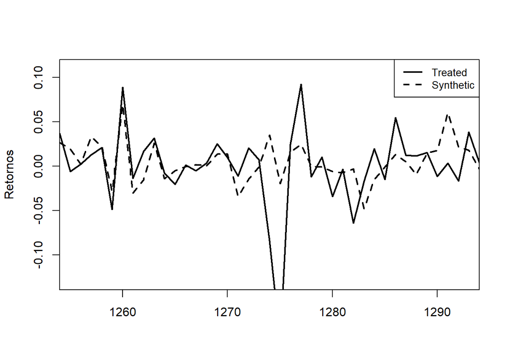

```r
path_plot<-path.plot(synth.res = out,dataprep.res = vale_controle,Ylab = 'Retornos',Xlab='')
```

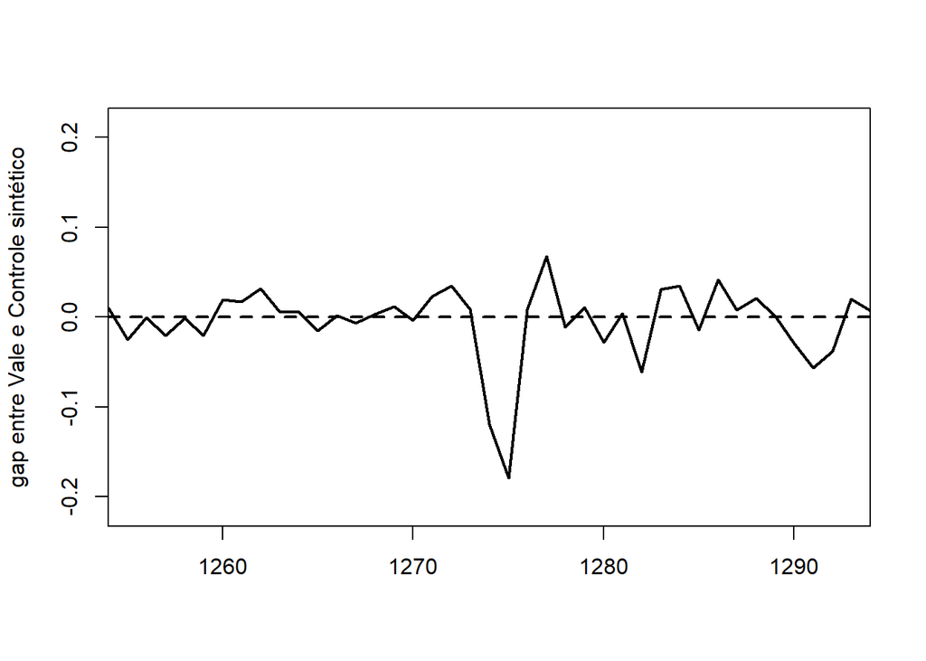

```r
gaps.plot(synth.res = out,dataprep.res = vale_controle,Main = '',Xlab = '',Ylab = 'gap entre Vale e Controle sintético')
```

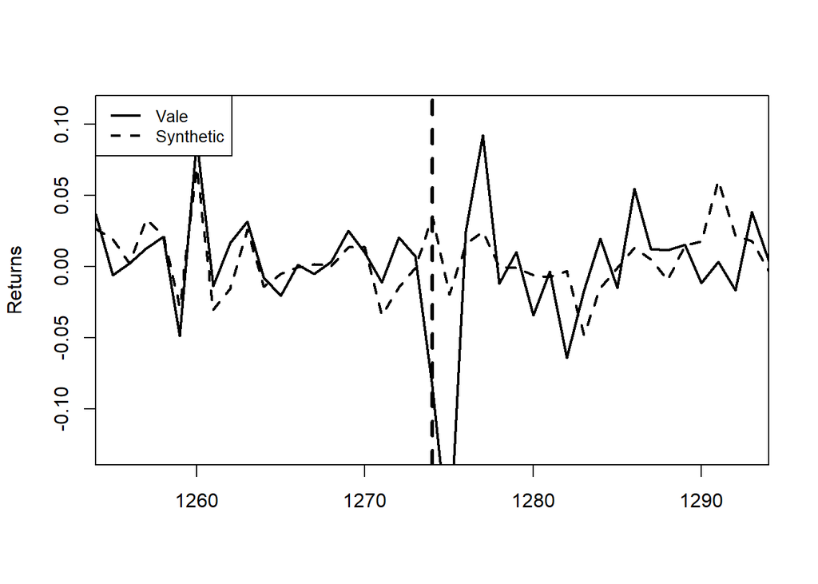

```r
#stargazer(tabelas$tab.pred,type = 'html',title = 'estimado controle e tratado')
#stargazer(tabelas$tab.v,type = 'html',title = 'Pesos das variáveis')

#pdf(file = "D:\\Onedrive - Aisha\\OneDrive\\Documentos\\Graduação Economia UDESC\\2019-1\\Estratégia em Finanças - Daniel\\Artigo da disciplina\\Fig_brumasynth.pdf", width = 12, height = 6)
path.plot(synth.res    = out,
          dataprep.res = vale_controle,
          Ylab         = c("Returns"),
          Xlab         = c(""),
          Legend       = c("Vale","Synthetic"),
          Legend.position = c("topleft")
)
abline(v=1274, lty=2, lwd=3)
```

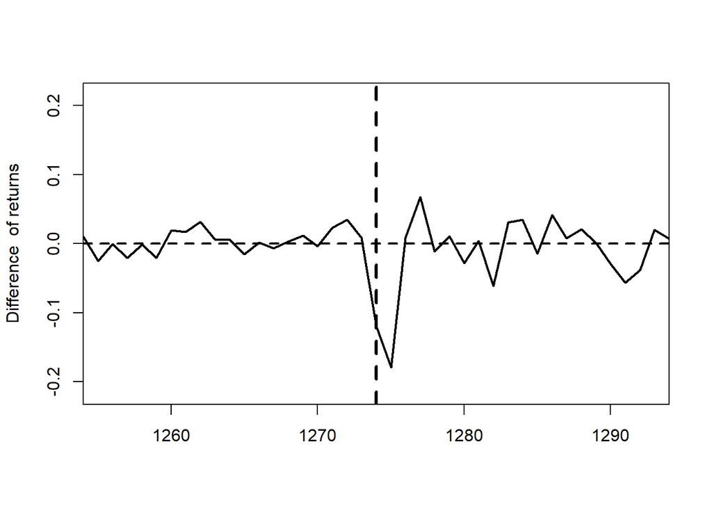

```r
#dev.off()

#pdf(file = "D:\\Onedrive - Aisha\\OneDrive\\Documentos\\Graduação Economia UDESC\\2019-1\\Estratégia em Finanças - Daniel\\Artigo da disciplina\\Fig_brumadiff.pdf", width = 12, height = 6)
gaps.plot(synth.res = out,dataprep.res = vale_controle,  Main = '',Xlab = '',Ylab = 'Difference  of returns')
abline(v=1274, lty=2, lwd=3)
```

```r
#dev.off()

# Placebo
placebos <- generate.placebos(dataprep.out =  vale_controle, synth.out = out)
```

[output not shown]

[output cut: 424 more lines]

```
## ****************
##  searching for synthetic control unit
##
##
## ****************
## ****************
## ****************
##
## MSPE (LOSS V): 0.002091248
##
## solution.v:
##  0.6441252 8.39277e-05 0.3557909
##
## solution.w:
##  1.13007e-05 5.42975e-05 7.4361e-06 1.8887e-05 1.5206e-05 2.04404e-05 7.9984e-06 2.06018e-05 3.1606e-06 2.14e-07 3.49861e-05 3.08217e-05 0.5964317 0.0001493798 4.39e-07 1.2452e-05 2.39801e-05 3.36189e-05 1.1086e-05 0.4029924 2.46414e-05 5.14918e-05 4.34304e-05
```

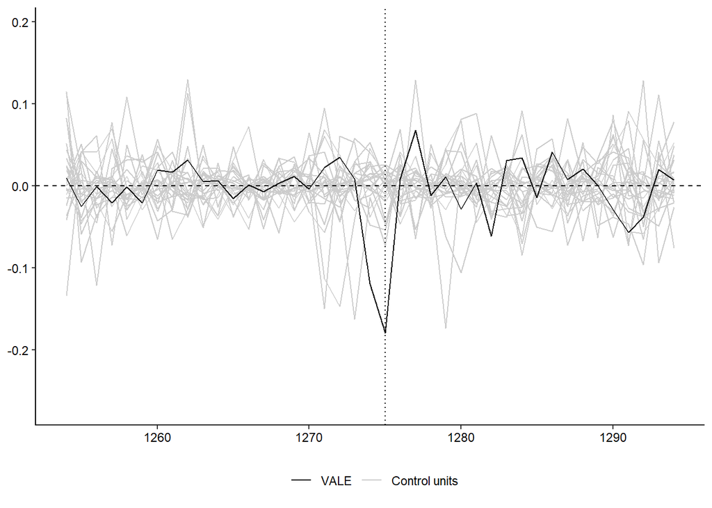

```r
#mspe.plot(placebos, discard.extreme = TRUE, mspe.limit = 20, plot.hist = FALSE)

#pdf(file = "D:\\Onedrive - Aisha\\OneDrive\\Documentos\\Graduação Economia UDESC\\2019-1\\Estratégia em Finanças - Daniel\\Artigo da disciplina\\Fig_brumaplacebo.pdf", width = 12, height = 6)
plot.placebos(placebos)
```

```r
#dev.off()
```